# Network visualization w R

Działanie oraz zastosowanie

Adrian Pilarczyk

Metoda wizualizacji danych sieciowych przy użyciu języka R. Dzięki bibliotekom takim jak igraph, network, ggraph, i visNetwork, R umożliwia tworzenie interaktywnych i atrakcyjnych grafik przedstawiających sieci.

Sieci te mogą reprezentować różnorodne typy danych, takie jak relacje społeczne, połączenia między stronami internetowymi, sieci neuronalne, czy też inne struktury złożone, gdzie węzły reprezentują obiekty, a krawędzie – relacje między nimi. Wizualizacja sieci w R jest użyteczna do analizy strukturalnej, odkrywania wzorców, oraz prezentacji złożonych zależności w przystępny wizualnie sposób.

Przejdźmy do przykładów, które pokazują nam zastosowanie network visualization w R:

```r
library(igraph)
```

Przykłady prostych grafów:

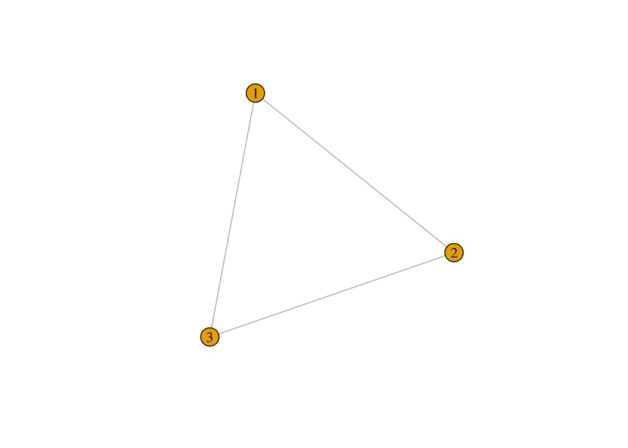

```r
g1 <- graph( edges=c(1,2, 2,3, 3, 1), n=3, directed=F )

plot(g1)
```

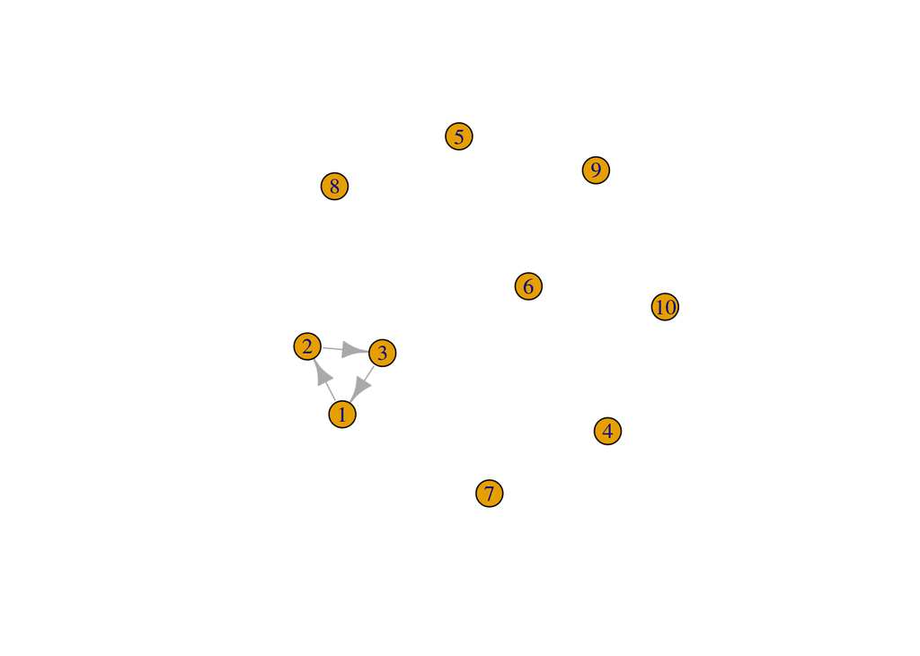

```r
g2 <- graph( edges=c(1,2, 2,3, 3, 1), n=10 )

plot(g2)
```

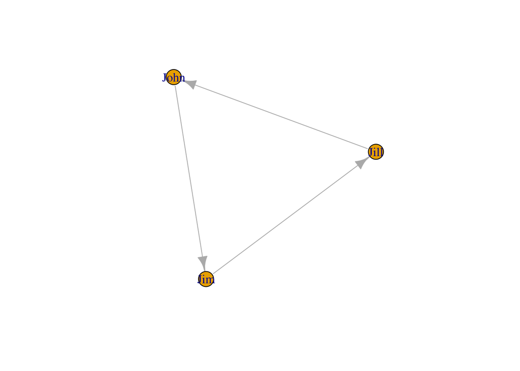

```r
g3 <- graph( c("John", "Jim", "Jim", "Jill", "Jill", "John"))
plot(g3)
```

Pakiet ten zawiera wiele opcji kosmetycznych oraz modyfikujących nasze grafy pod dane zastosowanie:

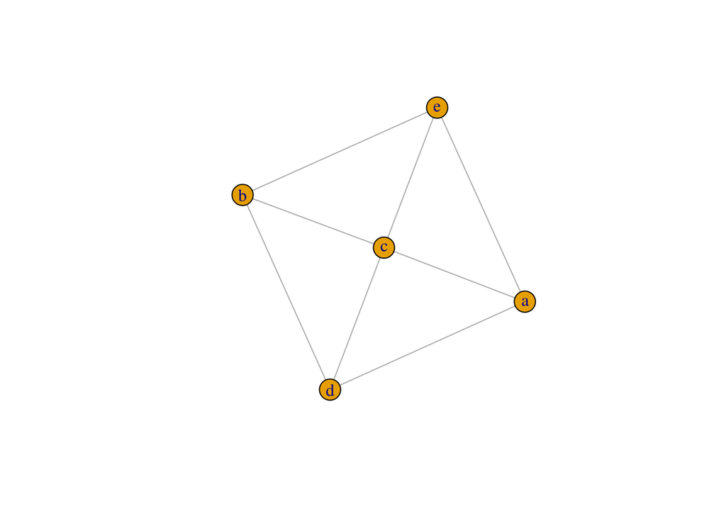

```r
plot(graph_from_literal(a:b:c---c:d:e))
```

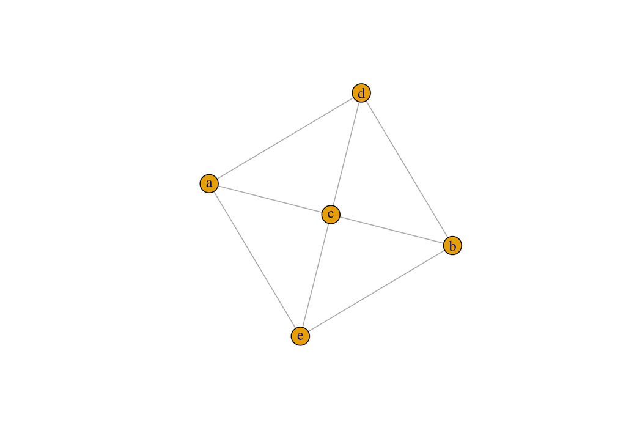

```r
plot(graph_from_literal(a:b:c---c:d:e))
```

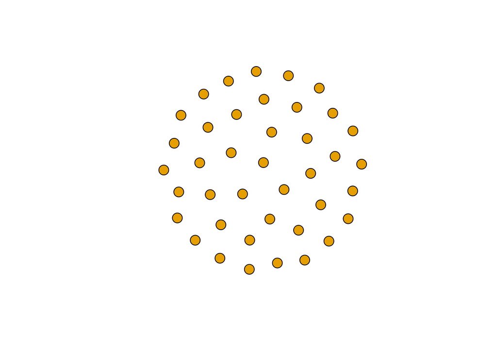

```r
eg <- make_empty_graph(40)

plot(eg, vertex.size=10, vertex.label=NA)
```

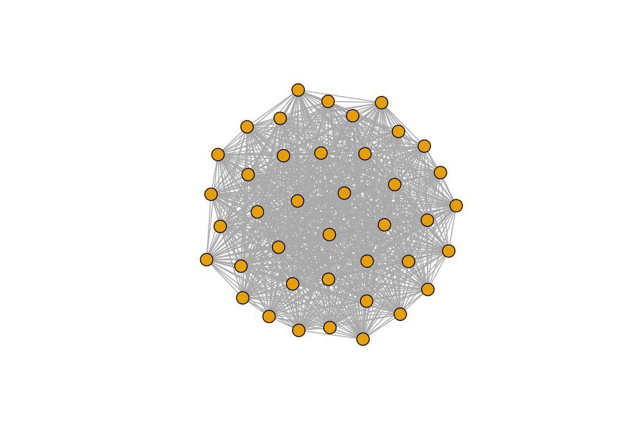

```r
fg <- make_full_graph(40)

plot(fg, vertex.size=10, vertex.label=NA)
```

Można tworzyć swoje własne proste przykłady nawet pokazujące relacje między ludźmi (np. kto komu podarował prezent na urodziny):

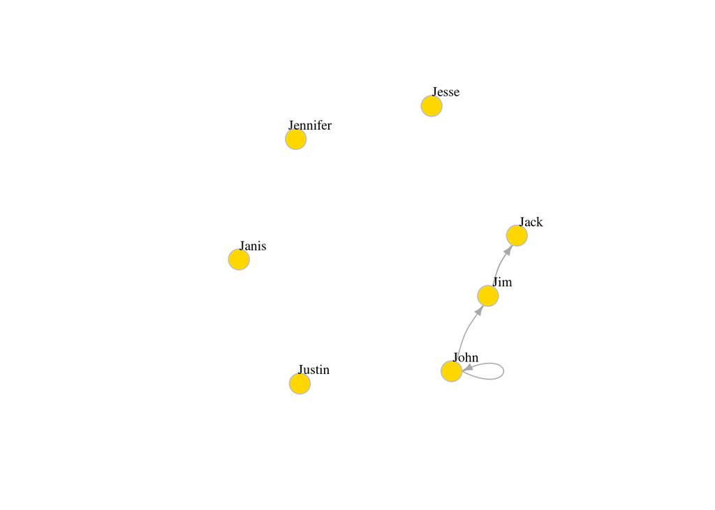

```r
g4 <- graph( c("John", "Jim", "Jim", "Jack", "Jim", "Jack", "John", "John"),

             isolates=c("Jesse", "Janis", "Jennifer", "Justin") )




plot(g4, edge.arrow.size=.5, vertex.color="gold", vertex.size=15,

     vertex.frame.color="gray", vertex.label.color="black",

     vertex.label.cex=0.8, vertex.label.dist=2, edge.curved=0.2)
```

Pakiet również pozwala sprawdzić w danym grafie krawędzie oraz wierzchołki:

```r
E(g4)
```

```
## + 4/4 edges from 48a83a4 (vertex names):
## [1] John->Jim  Jim ->Jack Jim ->Jack John->John
```

```r
V(g4)
```

```
## + 7/7 vertices, named, from 48a83a4:
## [1] John     Jim      Jack     Jesse    Janis    Jennifer Justin
```

Można również wyświetlić macierz przedstawiającą ilość połączeń pomiędzy danymi wierzchołkami:

```r
g4[]
```

```
## 7 x 7 sparse Matrix of class "dgCMatrix"
##          John Jim Jack Jesse Janis Jennifer Justin
## John        1   1    .     .     .        .      .
## Jim         .   .    2     .     .        .      .
## Jack        .   .    .     .     .        .      .
## Jesse       .   .    .     .     .        .      .
## Janis       .   .    .     .     .        .      .
## Jennifer    .   .    .     .     .        .      .
## Justin      .   .    .     .     .        .      .
```

Dodatkowo, jeżeli da się takie informacje umieścić w tabeli, można również nadać wagę lub cechę dla danego atrybutu grafu:

```r
V(g4)$gender <- c("male", "male", "male", "male", "female", "female", "male")

E(g4)$type <- "birthday"

E(g4)$weight <- 100
```

```r
edge_attr(g4)
```

```
## $type
## [1] "birthday" "birthday" "birthday" "birthday"
##
## $weight
## [1] 100 100 100 100
```

```r
vertex_attr(g4)
```

```
## $name
## [1] "John"     "Jim"      "Jack"     "Jesse"    "Janis"    "Jennifer" "Justin"
##
## $gender
## [1] "male"   "male"   "male"   "male"   "female" "female" "male"
```

Na prostym przykładzie pokazaliśmy jak wygląda sytuacja naszego przykładu z prezentami oraz rozdzielenie osób na płeć:

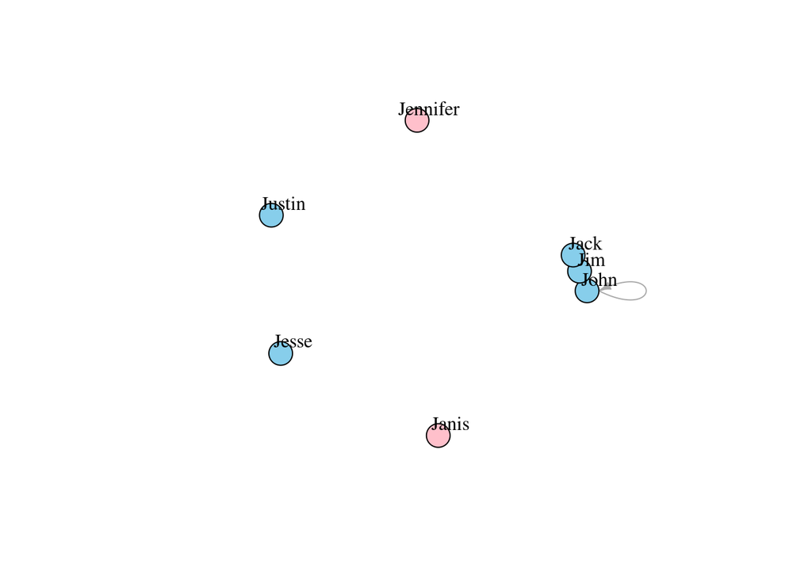

```r
plot(g4, edge.arrow.size=.5, vertex.label.color="black", vertex.label.dist=1.5,

     vertex.color=c( "pink", "skyblue")[1+(V(g4)$gender=="male")] )
```

Jeżeli dostalibyśmy dane od innej osoby, bardzo łatwo z nich stworzyć takie grafy:

```r
nodes <- read.csv("Dataset1-Media-Example-NODES.csv", header=T, as.is=T)

links <- read.csv("Dataset1-Media-Example-EDGES.csv", header=T, as.is=T)
```

```r
head(nodes)
```

|  | id | media | media.type | type.label | audience.size |
| --- | --- | --- | --- | --- | --- |
| 1 | s01 | NY Times | 1 | Newspaper | 20 |
| 2 | s02 | Washington Post | 1 | Newspaper | 25 |
| 3 | s03 | Wall Street Journal | 1 | Newspaper | 30 |
| 4 | s04 | USA Today | 1 | Newspaper | 32 |
| 5 | s05 | LA Times | 1 | Newspaper | 20 |
| 6 | s06 | New York Post | 1 | Newspaper | 50 |

```r
head(links)
```

|  | from | to | weight | type |
| --- | --- | --- | --- | --- |
| 1 | s01 | s02 | 10 | hyperlink |
| 2 | s01 | s02 | 12 | hyperlink |
| 3 | s01 | s03 | 22 | hyperlink |
| 4 | s01 | s04 | 21 | hyperlink |
| 5 | s04 | s11 | 22 | mention |
| 6 | s05 | s15 | 21 | mention |

```r
net <- graph_from_data_frame(d=links, vertices=nodes, directed=T)
net
```

```
## IGRAPH 8935902 DNW- 17 52 --
## + attr: name (v/c), media (v/c), media.type (v/n), type.label (v/c),
## | audience.size (v/n), weight (e/n), type (e/c)
## + edges from 8935902 (vertex names):
##  [1] s01->s02 s01->s02 s01->s03 s01->s04 s04->s11 s05->s15 s06->s17 s08->s09
##  [9] s08->s09 s03->s04 s04->s03 s01->s15 s15->s01 s15->s01 s16->s17 s16->s06
## [17] s06->s16 s09->s10 s08->s07 s07->s08 s07->s10 s05->s02 s02->s03 s02->s01
## [25] s03->s01 s12->s13 s12->s14 s14->s13 s13->s12 s05->s09 s02->s10 s03->s12
## [33] s04->s06 s10->s03 s03->s10 s04->s12 s13->s17 s06->s06 s14->s11 s03->s11
## [41] s12->s06 s04->s17 s17->s04 s08->s03 s03->s08 s07->s14 s15->s06 s15->s04
## [49] s05->s01 s02->s09 s03->s05 s07->s03
```

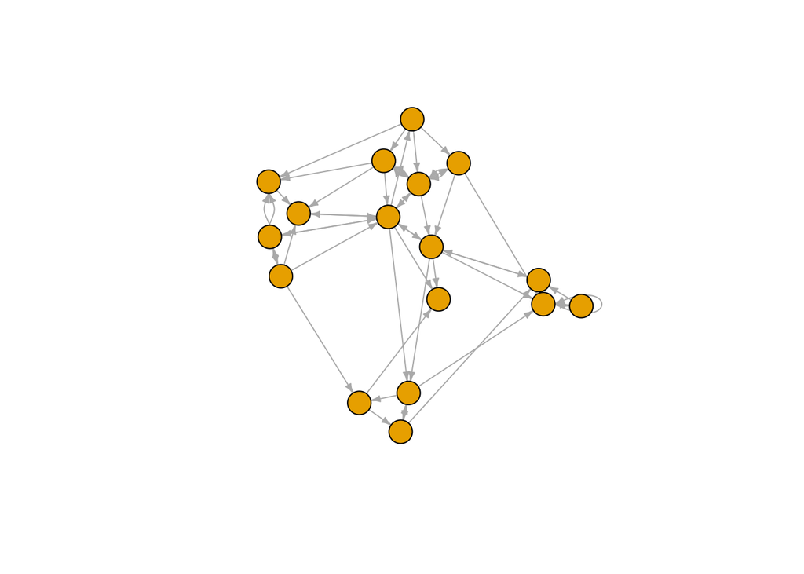

```r
plot(net, edge.arrow.size=.4,vertex.label=NA)
```

Za pomocą funkcji simplify możemy usunąć krawędzie, które prowadzą do pętli:

```r
net <- simplify(net, remove.multiple = F, remove.loops = T)
```

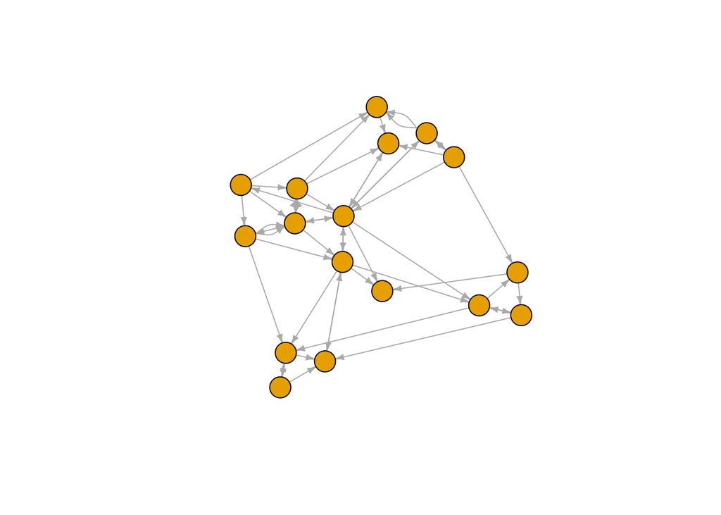

```r
plot(net, edge.arrow.size=.4,vertex.label=NA)
```

W zależności, jakie dane miały być pokazane na grafie, modyfikujemy go według naszych preferencji:

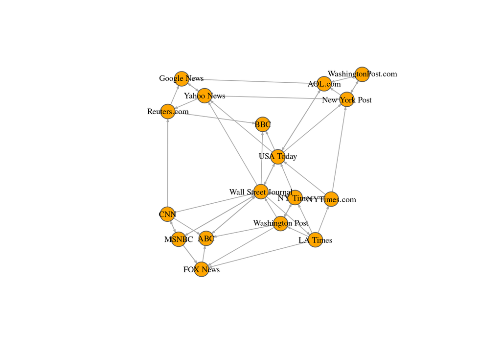

```r
plot(net, edge.arrow.size=.2, edge.curved=0,

     vertex.color="orange", vertex.frame.color="#555555",

     vertex.label=V(net)$media, vertex.label.color="black",

     vertex.label.cex=.7)
```

Można również go zmienić mając stan obecnego grafu na bardziej pokazujący, jaki portal do wiadomości jest najpopularniejszy w zależności od kategorii:

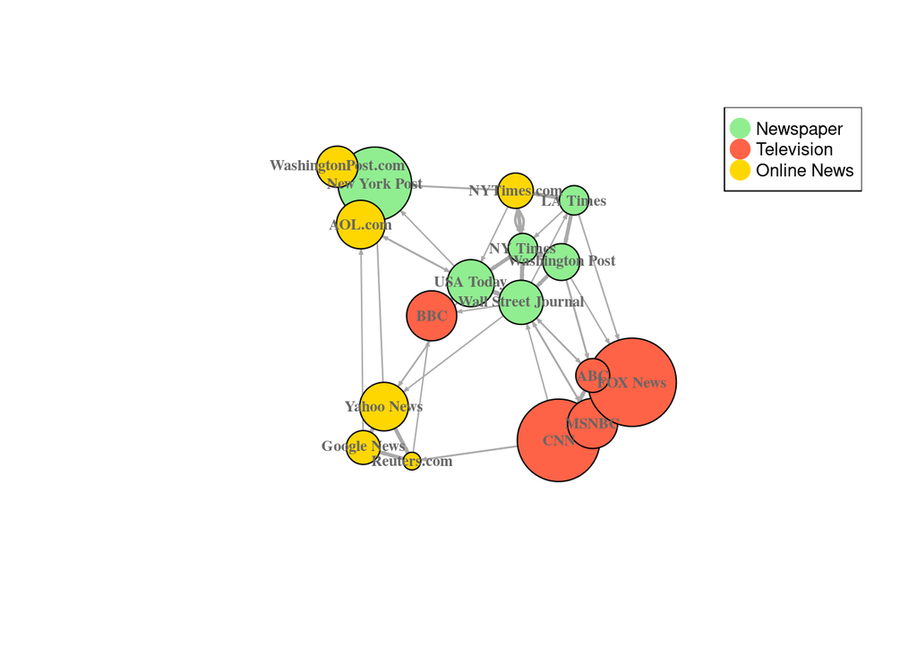

```r
colrs <- c("lightgreen", "tomato", "gold")
V(net)$color <- colrs[V(net)$media.type]
V(net)$size <- V(net)$audience.size
E(net)$arrow.size <- .2
E(net)$edge.color <- "blue"
E(net)$width <- 1+E(net)$weight/12

plot(net, vertex.label=V(net)$media,
     vertex.label.font=2, vertex.label.color="gray40",
     vertex.label.cex=.7, vertex.dist=2)


legend("topright", legend=c("Newspaper", "Television", "Online News"),
       col=colrs, pch=21, pt.bg=colrs, pt.cex=2, cex=0.8)
```

```r
library('visNetwork')
visNetwork(nodes, links, width="100%", height="400px")
```

[interactive chart not shown]

```r
vis.nodes <- nodes
vis.links <- links

vis.nodes$shape  <- "dot"
vis.nodes$shadow <- TRUE # Nodes will drop shadow
vis.nodes$title  <- vis.nodes$media # Text on click
vis.nodes$label  <- vis.nodes$type.label # Node label
vis.nodes$size   <- vis.nodes$audience.size # Node size
vis.nodes$borderWidth <- 2 # Node border width

vis.nodes$color.background <- c("lightgreen", "tomato", "gold")[nodes$media.type]
vis.nodes$color.border <- "black"
vis.nodes$color.highlight.background <- "orange"
vis.nodes$color.highlight.border <- "darkred"

vis.links$width <- 1+links$weight/10
vis.links$color <- "blue"
vis.links$arrows <- "middle"

visNetwork(vis.nodes, vis.links)
```

[interactive chart not shown]

```r
vis.links$smooth <- FALSE
vis.links$shadow <- FALSE

visnet <- visNetwork(vis.nodes, vis.links)
visnet
```

[interactive chart not shown]

```r
visOptions(visnet, highlightNearest = TRUE, selectedBy = "label")
```

[interactive chart not shown]

Na koniec ładne struktury z wykorzystaniem network visualization:

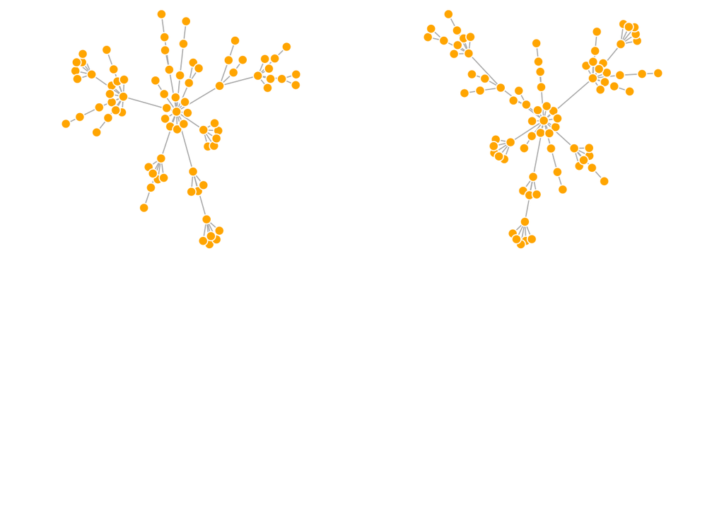

```r
net.bg <- sample_pa(80)

V(net.bg)$size <- 8

V(net.bg)$frame.color <- "white"

V(net.bg)$color <- "orange"

V(net.bg)$label <- ""

E(net.bg)$arrow.mode <- 0

par(mfrow=c(2,2), mar=c(0,0,0,0))

plot(net.bg, layout=layout_with_fr)

plot(net.bg, layout=layout_with_fr)
```